# Part II - New York City Bike-Sharing Project

## by Le Sy Khanh Duy

## Investigation Overview

In this investigation, I want to understand behavior of user base on their gender, type of user improve the business. Mainly, I focus on below information:

- Trip Count/duration (How long/How many the service was used)
- Gender (Who used the service)
- User Type (Who used the service)
- Monthly, Daily, Hourly (When they used the service)

## Dataset Overview

- Trip duration (seconds)
- Trip Start Time
- Trip End Time
- Start Station ID/Name
- End Station ID/Name
- User Type (Subcribers and Customers)
- Gender (Male, Female, Others)

## Bike Monthly Usage

We found that:

- Number of trip in September is highest.
- Number of trip in April is lowest.
- Bike usage increase in Summer (April~September), and decrease in winter.

There are some factor of weather such as temporatures may impact to bike usage. (example: in winter due to bad weather people don't like to use bike.)

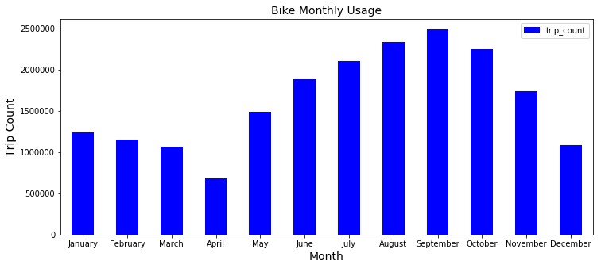

## Bike Hourly Usage

The Usage increased dramatically from 6AM - 6PM and peak at 6PM. This is a clue that most people use bike for commuting to work.

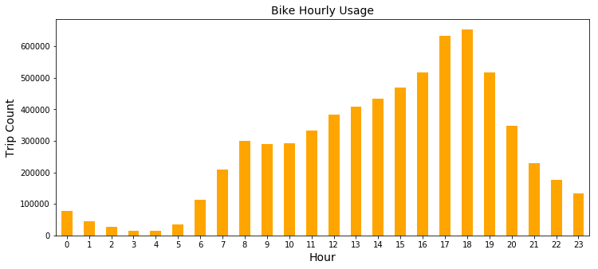

## Bike Usage By Gender

Male rides are nearly 2 times more than female rides

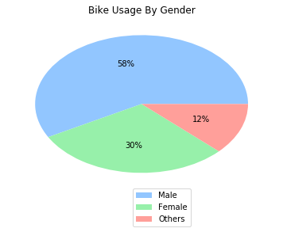

## Bike Usage Time By User Type

#### Subcribes:

- Most rides at 5PM-6PM in working days(Mon-Friday). The peak is at Wednesday 6PM.

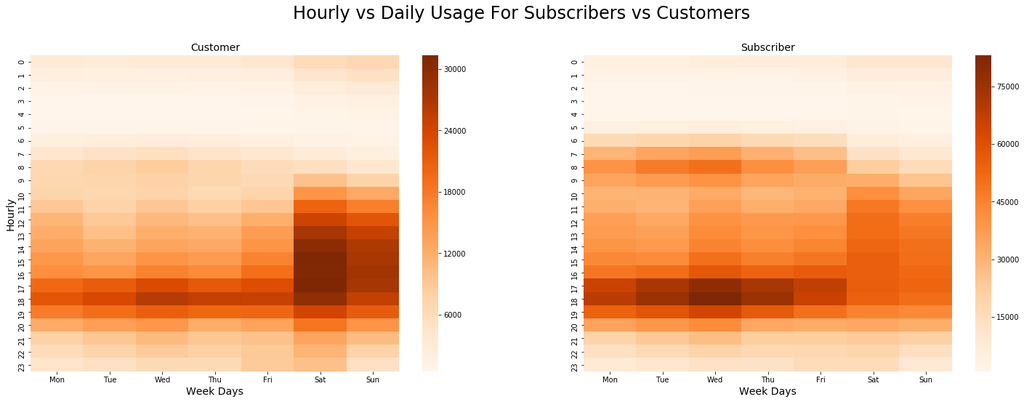